# DSCI 352 Report Out 3

Anthony Brennan  
December 5, 2019

### Recap: Question

- Question
  - Can I predict an expected goals scored, goal differential, and win probabilities for various European soccer matches using player data from FIFA video games?

### Recap: Datasets

- 4 Datasets from Kaggle: Game data, player data from Fifa 17, 18, & 19
  - Applying Fifa 17 to 2016-17 season, Fifa 18 to 2017-18 season, and Fifa 19 to 2018-19 season
- Data for 17 leagues
  - England (1st-4th divisions)
  - Germany, France, Italy, Spain (1st-2nd divisions)
  - Belgium, Netherlands, Portugal, Scotland, Turkey (1st division)
- Total of 19314 games
- 334 teams and ~9500 players for each of the 3 years

### Models

- Predicting goal differential
  - Created 2 different models using regression and svm models
- Predicting goals scored using
  - Created 2 different models using regression and svm models
- Win probabilities
  - 1st method use t-score probabilities on the predicted goal differential
  - 2nd method use poisson distributions on each team's predict goals scored

### Modeling Method 1 - t-score

Ratings

```
     Club  Overall GK Attacking Midfield Defense    Bench
927  Roma 82.36364 80      83.5    82.00   82.75 78.57143
902 Parma 73.27273 75      77.5    72.75   71.25 72.28571
```

```
        Club  Overall GK Attacking Midfield Defense    Bench
858 Mallorca 67.81818 68      66.5    69.75    66.5 66.14286
802  Granada 70.72727 69      71.5    72.00    69.5 67.42857
```

Regression Model

- lm(GoalDiff ~ HomeAttacking + AwayAttacking + HomeMidfield + AwayMidfield + HomeDefense + AwayDefense + HomeBench + AwayBench, training)

SVM Model

- svm(GoalDiff ~ HomeAttacking + AwayAttacking + HomeMidfield + AwayMidfield + HomeDefense + AwayDefense + HomeBench + AwayBench, data = training, kernel = “linear”, cost = 10, scale = FALSE)

### Modeling Method 1 - t-score

Ratings

```
        Club  Overall GK Attacking Midfield Defense    Bench
927     Roma 82.36364 80      83.5    82.00   82.75 78.57143
902    Parma 73.27273 75      77.5    72.75   71.25 72.28571
858 Mallorca 67.81818 68      66.5    69.75   66.50 66.14286
802  Granada 70.72727 69      71.5    72.00   69.50 67.42857
```

Regression Model

```
   HomeTeam AwayTeam pred_gd HomeWin AwayWin Draw
19     Roma    Parma    1.81    0.79    0.07 0.13
13 Mallorca  Granada   -0.12    0.35    0.41 0.25
```

SVM Model

```
   HomeTeam AwayTeam   Fit HomeWin AwayWin Draw
19     Roma    Parma  2.04    0.82    0.06 0.11
13 Mallorca  Granada -0.32    0.31    0.46 0.23
```

### Regression Validation

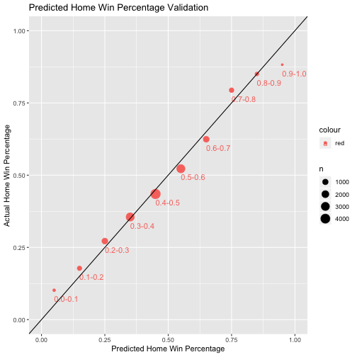

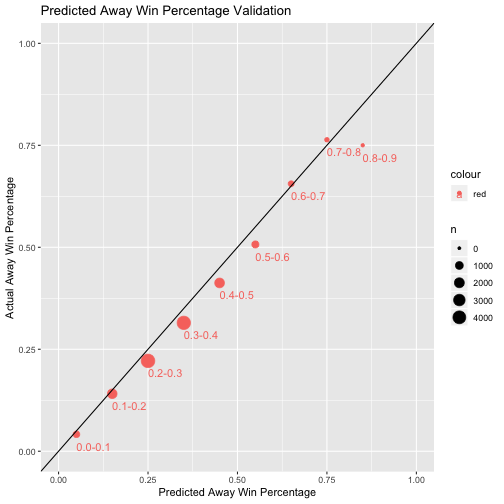

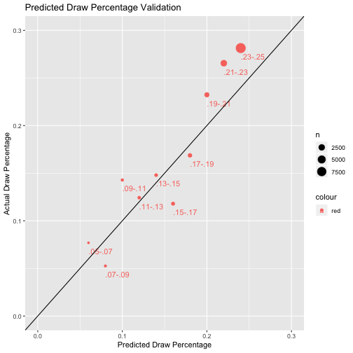

### Modeling Method 2 - Poisson

Regression Model

- Home Goals Scored
  - lm(FTHG ~ HomeOverall + AwayOverall + HomeAttacking + AwayDefense + AwayGoalkeeper, training)
- Away Goals Scored
  - lm(FTAG ~ HomeOverall + AwayOverall + AwayAttacking + HomeDefense + HomeGoalkeeper, training)

SVM Model

- Home Goals Scored
  - svm(FTHG ~ HomeOverall + AwayOverall + HomeAttacking + AwayDefense + AwayGoalkeeper, data = training, kernel = “linear”, cost = 10, scale = FALSE)
- Away Goals Scored
  - svm(FTAG ~ HomeOverall + AwayOverall + AwayAttacking + HomeDefense + HomeGoalkeeper, data = training, kernel = “linear”, cost = 10, scale = FALSE)

### Modeling Method 2 - Poisson

```
  poisson2[, 2] Pred Goal0 Goal1 Goal2 Goal3 Goal4 Goal5
1          Roma 2.44  0.09  0.21  0.26  0.21  0.13  0.06
2         Parma 0.60  0.55  0.33  0.10  0.02  0.00  0.00
```

```
  poisson[, 2] Away0 Away1 Away2 Away3 Away4 Away5
1        Home0  0.05  0.03  0.01  0.00     0     0
2        Home1  0.12  0.07  0.02  0.00     0     0
3        Home2  0.14  0.09  0.03  0.01     0     0
4        Home3  0.12  0.07  0.02  0.00     0     0
5        Home4  0.07  0.04  0.01  0.00     0     0
6        Home5  0.03  0.02  0.01  0.00     0     0
```

### Modeling Method 2 - Poisson

Ratings

```
        Club  Overall GK Attacking Midfield Defense    Bench
927     Roma 82.36364 80      83.5    82.00   82.75 78.57143
902    Parma 73.27273 75      77.5    72.75   71.25 72.28571
858 Mallorca 67.81818 68      66.5    69.75   66.50 66.14286
802  Granada 70.72727 69      71.5    72.00   69.50 67.42857
```

Regression Model

```
   HomeTeam AwayTeam HomePred AwayPred HomeWin AwayWin Draw
19     Roma    Parma     2.44     0.60    0.74    0.07 0.15
13 Mallorca  Granada     1.18     1.41    0.31    0.42 0.26
```

SVM Model

```
   HomeTeam AwayTeam HomePred AwayPred HomeWin AwayWin Draw
19     Roma    Parma     2.31     0.61    0.73    0.08 0.16
13 Mallorca  Granada     1.02     1.39    0.27    0.45 0.27
```

### Regression Validation

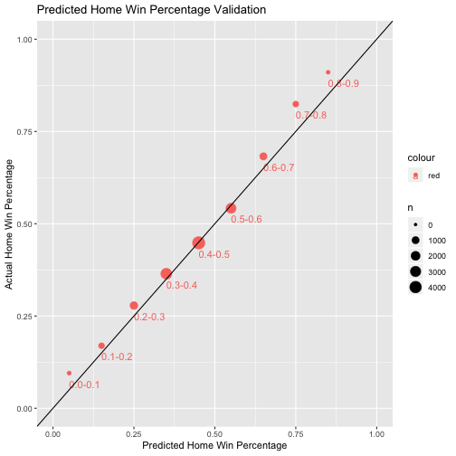

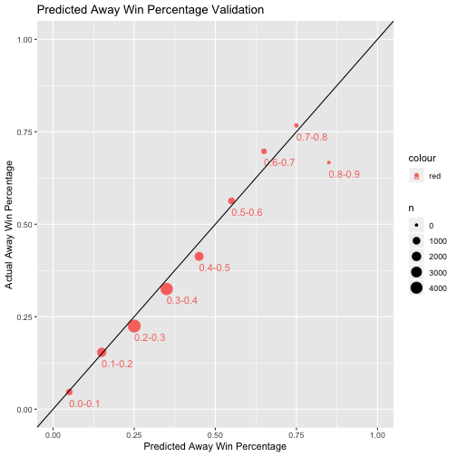

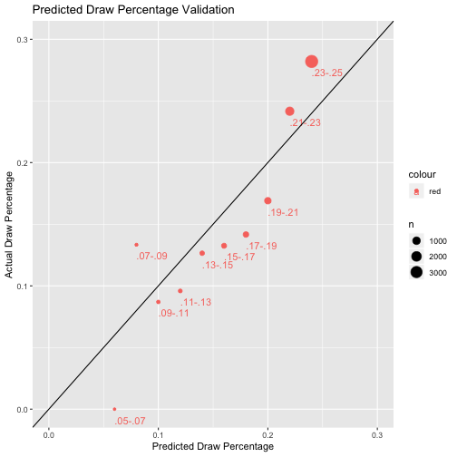

### Final Standings Example - Italy Serie A 2018/2019

```
   italyclubs  wins draws losses pred_points actual_points
1    Juventus 28.28  5.54   4.18       90.37            90
2      Napoli 23.71  7.07   7.22       78.19            79
3       Inter 23.60  7.12   7.28       77.93            69
4        Roma 21.41  7.66   8.93       71.89            66
5       Milan 20.79  7.77   9.44       70.14            68
6       Lazio 19.68  7.96  10.37       66.98            59
7      Torino 14.53  8.43  15.04       52.03            63
8    Atalanta 14.17  8.40  15.42       50.92            69
9   Sampdoria 13.45  8.41  16.14       48.76            53
10    Bologna 12.80  8.42  16.78       46.81            44
11 Fiorentina 12.75  8.41  16.84       46.66            41
12     Chievo 12.09  8.32  17.59       44.59            20
13      Genoa 11.74  8.34  17.92       43.55            38
14   Cagliari 11.71  8.31  17.98       43.44            41
15   Sassuolo 11.32  8.25  18.43       42.20            43
16    Udinese 11.29  8.25  18.46       42.12            43
17       Spal 10.57  8.14  19.29       39.85            42
18     Empoli  9.29  7.92  20.79       35.79            38
19      Parma  9.03  7.82  21.14       34.92            41
20  Frosinone  8.65  7.76  21.59       33.70            25
```

### Final Standings Example - Spain La Liga Segunda Division 2016/2017

```
       esp2clubs  wins draws losses pred_points actual_points
1        Levante 22.70  9.28  10.01       77.40            84
2         Getafe 19.54  9.85  12.61       68.46            68
3      Vallecano 18.21  9.96  13.83       64.59            53
4         Girona 18.11 10.00  13.89       64.33            70
5        Almeria 17.38 10.05  14.57       62.20            51
6         Oviedo 17.21 10.00  14.78       61.64            61
7       Zaragoza 16.93 10.03  15.05       60.80            50
8       Tenerife 16.60 10.03  15.37       59.82            66
9     Valladolid 16.43 10.03  15.53       59.33            63
10         Cadiz 16.12 10.05  15.83       58.41            64
11     Gimnastic 15.33 10.03  16.64       56.01            52
12         Elche 15.28 10.04  16.68       55.87            43
13        Huesca 15.23 10.04  16.73       55.74            63
14 Reus Deportiu 15.09 10.05  16.86       55.32            55
15      Alcorcon 15.09 10.06  16.86       55.32            50
16          Lugo 15.03 10.02  16.94       55.12            55
17       Cordoba 14.91 10.04  17.05       54.77            55
18      Numancia 14.30  9.99  17.71       52.89            50
19      Mallorca 14.25 10.01  17.74       52.76            45
20     Sevilla B 13.69  9.97  18.34       51.04            53
21      Mirandes 12.58  9.84  19.58       47.58            41
22   UCAM Murcia 12.39  9.84  19.78       47.00            48
```